# My Summer Holiday

Cormac Monaghan

cormac.monaghan@mu.ie

Hamilton Institute, Maynooth University

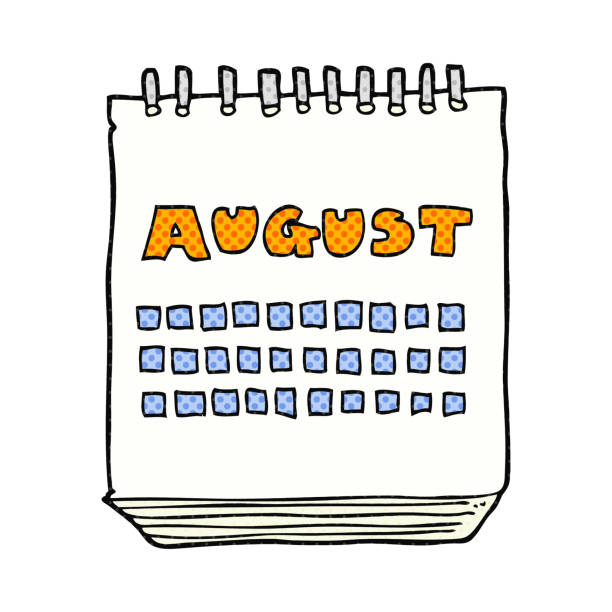

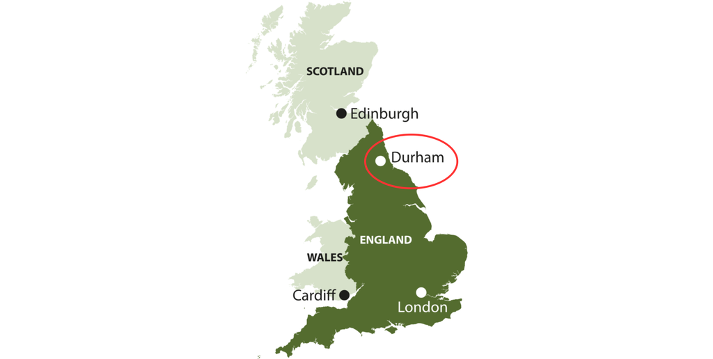

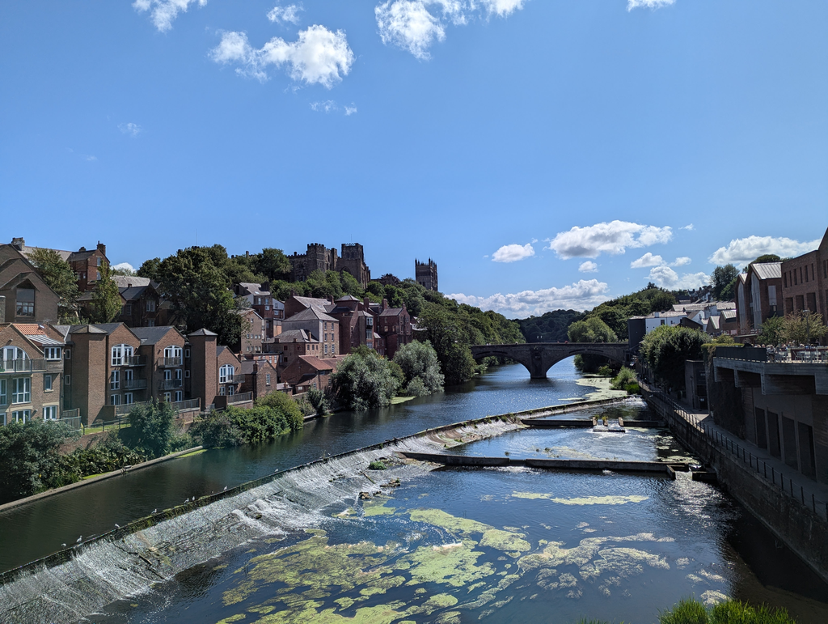

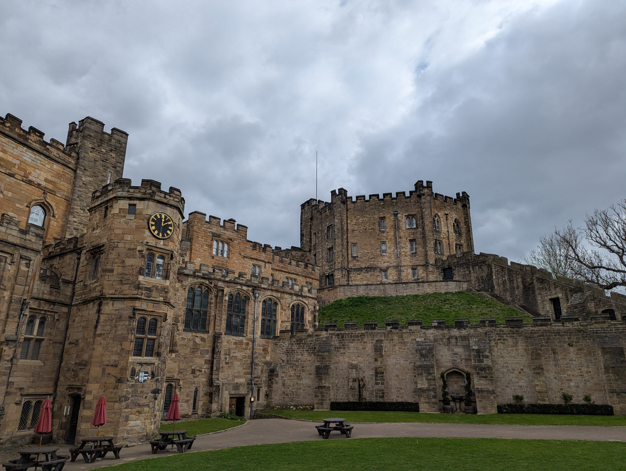

[figure not shown]

[figure not shown]

Professor Fuschia Sirois (Durham University)

[figure not shown]

[figure not shown]

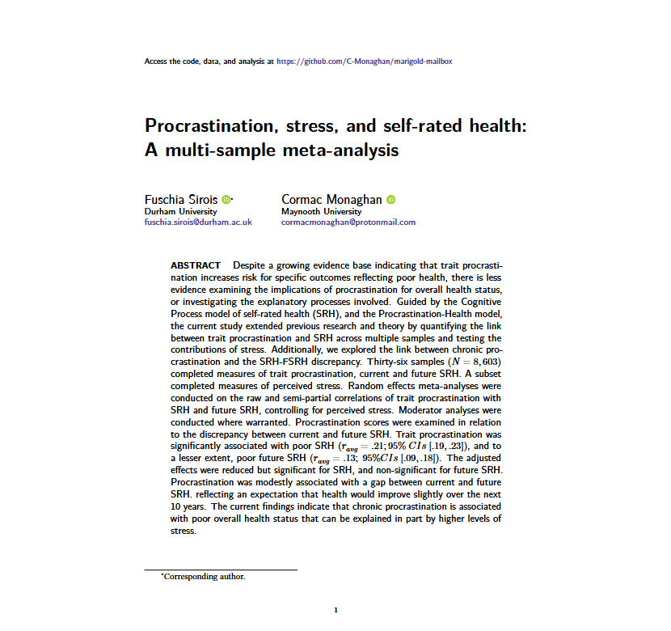

[figure not shown]

**Study 1: An experimental test of procrastination and social norms**

**Study 2: An experimental test of procrastination and social norms with young and older adults**

**Study 3: An experimental test of procrastination and social norms: The role of perspective**

## Social Norms

### What are social norms

- Shared, often **unwritten** rules that guide what is seen as **acceptable and appropriate behaviour** within a group or community.
- Social norms help to maintain **order and predictability** in social life.
  - 🗨️ Saying “please” or “thank you.”
  - 🚪 Holding the door for someone.
- Violating social norms often provokes **negative social reactions**<sup>1</sup>.

**Disapproval**

**Exclusion**

**Embarrassment**

## Social Norms

### Procrastination and social norms

- Failing to meet social or task-related expectations can lead others to question one’s **reliability or worth**.
- Chronic procrastination often clashes with norms of **responsibility, punctuality, and self-discipline**.
- As a result, procrastinators may be **socially devalued**<sup>2</sup>.

**Lazy**

**Unreliable**

**Weak**

# **Study 1**

## Social Norms

### Procrastination and social norms

Procrastination is not just a personal failure — it’s also a **socially evaluated behaviour**.

## Social Norms

### Age differences in social norms

- How procrastination is judged may vary by age.
- Socioemotional selectivity theory<sup>3</sup> proposes that as people age and perceive their remaining time as limited, they increasingly prioritize **emotionally meaningful, present-focused goals**.
  - Potentially heighten the perceived cost of delaying important tasks.
- Alternatively, older adults often develop structured routines, pragmatic prioritization strategies, and emotional regulation skills.
  - **Life experience** may lead to greater acceptance.

**Competing lines of thought**

Older adults might judge procrastination more negatively due to limited time horizons, or more leniently due to greater acceptance and coping strategies.

# **Study 2**

## Age differences in social norms

### Research plan

- Recruited 200 participants (100 younger & 100 older adults).
- Used [Prolific](https://www.prolific.com/) to collect data.
- Presented **multiple** procrastination / non-procrastination scenarios.
  - General procrastination
  - Health procrastination
  - Financial procrastination
- Participants provided ratings for several **bipolar adjectives**.
- Analysed data using a **multilevel model**.

## Age differences in social norms

### Research questions

This project was pre-registered on the Open Science Framework: https://osf.io/kjybe

While we had many research questions, our **primary questions** were:

- Examining whether the social norms for general vs. health vs. financial procrastination differ, both within individuals, and compared to a control group.
- Examining whether negative social norms associated with procrastination differ between age cohorts (younger vs older adults).

[figure not shown]

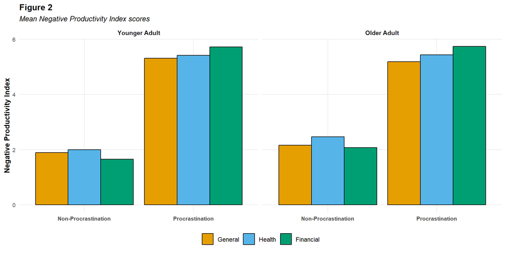

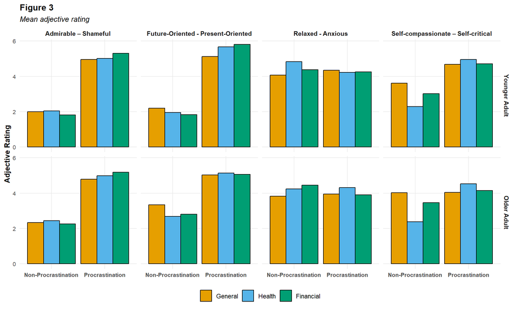

# **Multilevel model results**

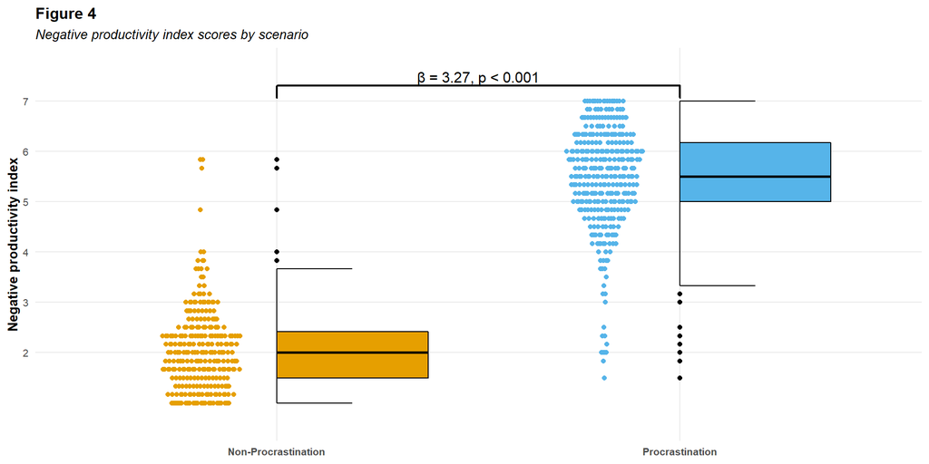

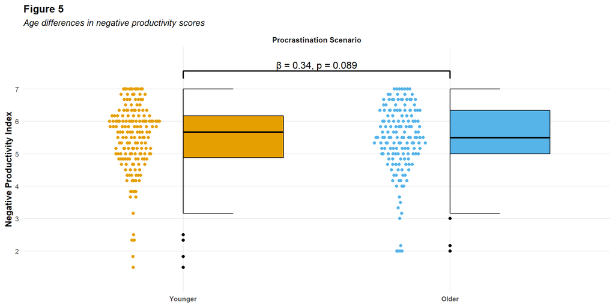

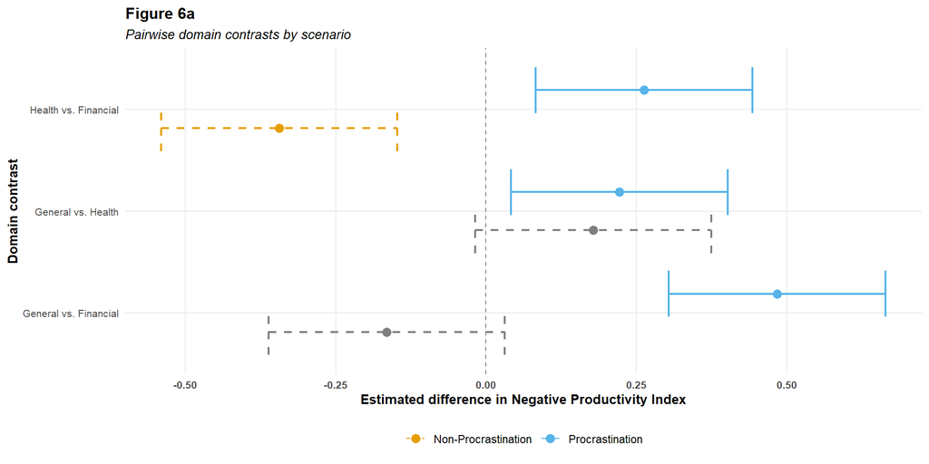

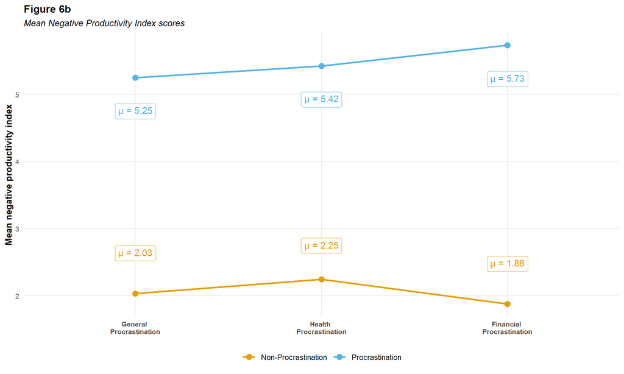

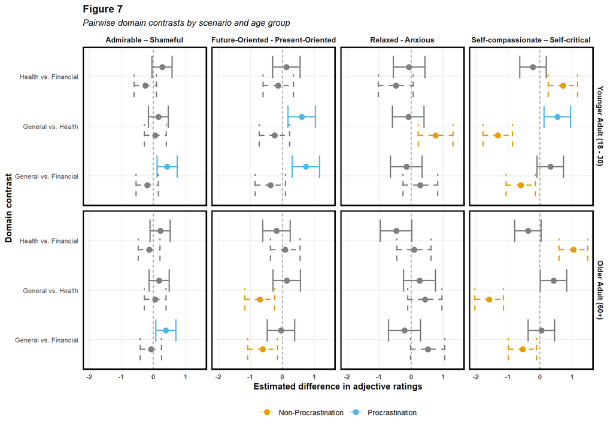

## Age differences in social norms

### Conclusions

**Productivity**

- Health procrastination is perceived as more negatively productive than general procrastination.
- However, financial procrastination is perceived as more negatively productive than both general or health procrastination.

**Adjective Ratings**

- Both younger and older adults perceive financial procrastination as more shameful than general procrastination.
- Younger adults perceive both health and financial procrastination as more present oriented than general procrastination.

## Age differences in social norms

### Conclusions

Procrastination may be seen as a **universally negative social behaviour**, irrespective of age.

## References

1. Van Kleef, G. A., Wanders, F., Stamkou, E., & Homan, A. C. (2015). The social dynamics of breaking the rules: Antecedents and consequences of norm-violating behavior. *Current Opinion in Psychology*, *6*, 25–31. https://doi.org/10.1016/j.copsyc.2015.03.013

2. Giguère, B., Sirois, F. M., & Vaswani, M. (2016). Delaying things and feeling bad about it? A norm-based approach to procrastination. In *Procrastination, health, and well-being* (pp. 189–212). Elsevier.

3. Carstensen, L. L. (2021). Socioemotional selectivity theory: The role of perceived endings in human motivation. *The Gerontologist*, *61*(8), 1188–1196. https://doi.org/10.1093/geront/gnab116